# Dental Technology Trends in Clinical Trials

Sanya Chauhan

2026

## Overview

This analysis examines which emerging dental technologies are being tested in registered clinical trials and how research activity has changed over time. Data was retrieved from ClinicalTrials.gov — the U.S. federal registry of clinical studies worldwide.

Total trials analyzed: 4,422 dental trials (2000-2024)

Technologies examined: Dental Implants, Lasers, AI-assisted diagnosis, CAD/CAM digital workflows, Teledentistry, and Robotics

## Methods

All dental-related trials were downloaded from ClinicalTrials.gov and imported into R. Trials were classified into technology categories using keyword detection across trial titles and summaries. Analysis was conducted using R with tidyverse packages.

## Key Findings

### 1. Trial Counts by Technology Category

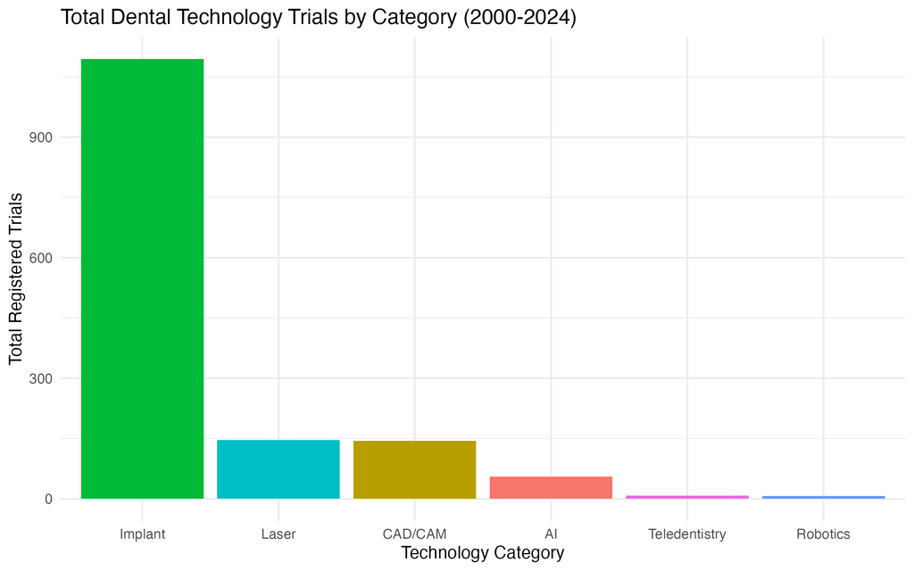

### 2. Technology Trends Over Time

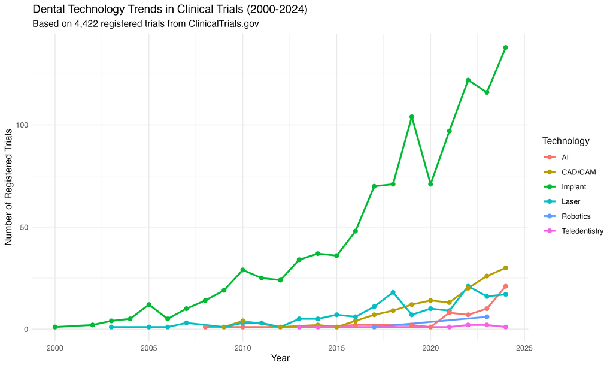